# Weight Lifting Exercises: predicting how well are done

EPP

February 24, 2016

## Executive summary

Six young health participants were asked to perform one set of 10 repetitions of the Unilateral Dumbbell Biceps Curl in five different fashions: exactly according to the specification (Class A), throwing the elbows to the front (Class B), lifting the dumbbell only halfway (Class C), lowering the dumbbell only halfway (Class D) and throwing the hips to the front (Class E).  
Based on data from accelerometers on the belt, forearm, arm, and dumbell of the participants, the goal is determine the best method for predicting how well future exercises are done.  
Several methods are tested and “random forest” gets the best accuracy.

## Getting data

```r
setwd("~/R/Coursera/machlearn/project")
data <- read.csv("pml-training.csv")
validation <- read.csv("pml-testing.csv")
```

## Cleaning data

We can find 159 variables in the data. Some of them not related with classe, others classified as factors but actually numbers, and others with more than 90% of NAs values. Only completed cases (rows without NAs) are considered by machine learning methods, so it is important to eliminate NAs.

After:

- removing non metric variables as username, timestamps and windows;
- converting factors to numbers;
- removing variables with more than 50% of NAs;
- removing near zero covariates;
- for the rest of NAs, imputing medians (not necessary);

there are 52 numeric variables left, all of them without NAs.

```r
data <- data[,-c(1:7)]
validation <- validation[,-c(1:7)]

n <- ncol(data)-1
colNA <- c()
for (i in 1:n) {
        if (is.factor(data[,i])) {data[,i] <- as.numeric(data[,i])}
        if (sum(is.na(data[,i]))/length(data)>0.5) {colNA <- c(colNA, i)}
        }
for (i in 1:n) {if (is.factor(validation[,i])) {validation[,i] <- as.numeric(validation[,i])}}
data <- data[,-colNA]
validation <- validation[,-colNA]

library(caret, warn.conflicts=FALSE, quietly=TRUE)
nsv <- nearZeroVar(data, saveMetrics = FALSE)
data <- data[,-nsv]
validation <- validation[,-nsv]

sum(is.na(data))
```

```
## [1] 0
```

```r
sum(is.na(validation))
```

```
## [1] 0
```

## Creating partitions

```r
set.seed(8888)
inTrain = createDataPartition(data$classe, p = 0.7)[[1]]
training = data[ inTrain,]
testing = data[-inTrain,]
```

## Testing methods

We are going to test two different methods with and without cross validation:

- random forest,
- random forest with cross validation,
- generalized boosted models,
- generalized boosted models with cross validation,

and then we will select the method with the minimum out-of-sample error (or the maximum accuracy).

The reason to select these methods is that random forest and boosting are the two top performing algorithms in prediction contests, and the accuracy of random forest.

### Random Forest

```r
library(randomForest, warn.conflicts=FALSE, quietly=TRUE)
set.seed(7777)
mf_rf <- randomForest(classe~., data=training)
pred_rf <- predict(mf_rf, testing)
acc_rf <- confusionMatrix(testing$classe, pred_rf)
acc_rf$overall
```

```
##       Accuracy          Kappa  AccuracyLower  AccuracyUpper   AccuracyNull
##      0.9964316      0.9954860      0.9945505      0.9977898      0.2853016
## AccuracyPValue  McnemarPValue
##      0.0000000            NaN
```

### Random Forest with Cross Validation

```r
set.seed(7777)
mf_rf2 <- train(classe~., data=training, method="rf", trControl=trainControl(method="cv", number=5))
pred_rf2 <- predict(mf_rf2, testing)
acc_rf2 <- confusionMatrix(testing$classe, pred_rf2)
acc_rf2$overall
```

```
##       Accuracy          Kappa  AccuracyLower  AccuracyUpper   AccuracyNull
##      0.9942226      0.9926917      0.9919359      0.9959958      0.2851317
## AccuracyPValue  McnemarPValue
##      0.0000000            NaN
```

### Generalized Boosted Model

```r
library(gbm, warn.conflicts=FALSE, quietly=TRUE)
set.seed(7777)
mf_gbm <- gbm(classe~., data=training, distribution="multinomial")
pred_gbm <- predict(mf_gbm, testing, type="response", n.trees=100)
p.pred_gbm <- apply(pred_gbm, 1, function(i) {dimnames(pred_gbm)[[2]][which.max(i)]})
acc_gbm <- confusionMatrix(testing$classe, p.pred_gbm)
acc_gbm$overall
```

```
##       Accuracy          Kappa  AccuracyLower  AccuracyUpper   AccuracyNull
##   5.124894e-01   3.779996e-01   4.996303e-01   5.253360e-01   3.785896e-01
## AccuracyPValue  McnemarPValue
##   1.307887e-96  2.806496e-298
```

### Generalized Boosted Model with Cross Validation

```r
set.seed(7777)
mf_gbm2 <- gbm(classe~., data=training, cv.folds=5, distribution="multinomial")
pred_gbm2 <- predict(mf_gbm2, testing, type="response")
```

```
## Using 100 trees...
```

```r
p.pred_gbm2 <- apply(pred_gbm2, 1, function(i) {dimnames(pred_gbm2)[[2]][which.max(i)]})
acc_gbm2 <- confusionMatrix(testing$classe, p.pred_gbm2)
acc_gbm2$overall
```

```
##       Accuracy          Kappa  AccuracyLower  AccuracyUpper   AccuracyNull
##   5.128292e-01   3.785872e-01   4.999702e-01   5.256755e-01   3.768904e-01
## AccuracyPValue  McnemarPValue
##   1.383949e-99  6.481169e-299
```

### Results

| **METHOD** | RF | RF+CV | GBM | GBM+CV |
| --- | --- | --- | --- | --- |
| **TEST ACCURACY** | 0.9964316 | 0.9942226 | 0.5124894 | 0.5128292 |
| **TEST ERROR** | 0.0035684 | 0.0057774 | 0.4875106 | 0.4871708 |

The best method is **Random Forest** without Cross Validation. The reason for this result is that in random forests there is no need for cross-validation or a separate test set to get an unbiased estimate of the test set error. It is estimated internally, and using cross-validation implies a smaller training dataset and none advantage.

```r
acc_rf$table
```

```
##           Reference
## Prediction    A    B    C    D    E
##          A 1673    0    0    1    0
##          B    6 1131    2    0    0
##          C    0    5 1020    1    0
##          D    0    0    3  960    1
##          E    0    0    1    1 1080
```

```r
acc_rf$overall[c(1,3:4)]
```

```
##      Accuracy AccuracyLower AccuracyUpper
##     0.9964316     0.9945505     0.9977898
```

```r
testing$predRight <- pred_rf == testing$classe
mf_rf$importance[order(mf_rf$importance, decreasing=TRUE),][1:3]
```

```
##     roll_belt      yaw_belt pitch_forearm
##      875.1560      604.5538      553.0881
```

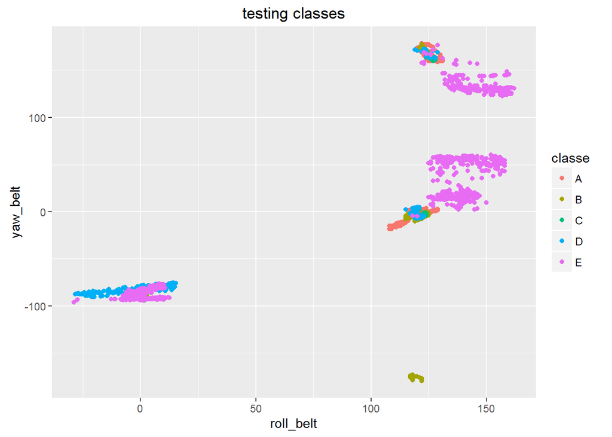

```r
qplot(roll_belt, yaw_belt, col=classe, data=testing, main="testing classes")
```

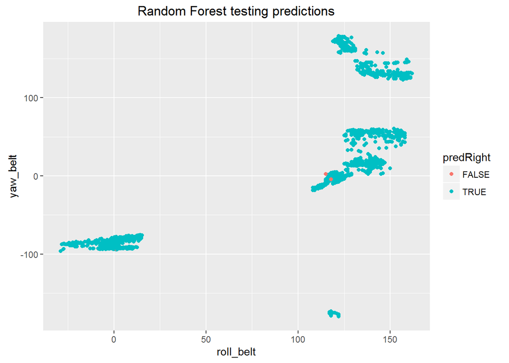

```r
qplot(roll_belt, yaw_belt, col=predRight, data=testing, main="Random Forest testing predictions")
```

```r
predV <- predict(mf_rf, validation)
```

> The **prediction** for the new data is: **B, A, B, A, A, E, D, B, A, A, B, C, B, A, E, E, A, B, B, B**